# Introduction

The effectiveness of this framework is shown through the Schlogl model, a remarkable example of a reaction network, which illustrates bistability with two steady state solutions (Schlögl 1972).

# How to start

Before starting the analysis we have to install (1) GreatSPN GUI, (2) docker, and (3) the R package **devtools** for installing *EPIMOD*. GreatSPN GUI, the graphical editor for drawing Petri Nets formalisms, is available online ([link to install GreatSPN](http://www.di.unito.it/~amparore/mc4cslta/editor.html)), and it can be installed following the steps showed therein. Then, the user must have docker installed on its computer for exploiting the *epimod*’s docker images (for more information on the docker installation see: [link to install docker](https://docs.docker.com/engine/installation/)), and to have authorization to execute docker commands reported in the command page of function install docker. To do this the following commands must be executed.

1. Create the docker group.

```
    $ sudo groupadd docker
```

1. Add your user to the docker group.

```
    $ sudo usermod -aG docker $USER
```

The R package *devtools* has to be installed to run *epimod*:

```
install.packages("devtools")
library(devtools)
install_github("qBioTurin/epimod", dependencies=TRUE)

library(epimod)
```

Then, the following function must be used to download all the docker images used by *epimod*:

```
downloadContainers()
```

## Something to know

All the *epimod* functions print the following information:

- *Docker ID*, that is the CONTAINER ID which is executed by the function;
- *Docker exit status*, if 0 then the execution completed with success, otherwise an error log file is saved in the working directory.

# Cases of study

In this section, we show the steps necessary to model a reaction network that exhibits bistability. The model recently attracted renewed interest due to its mapping onto biologically relevant models with bistability, e.g. (E. M. Ozbudak and Oudenaarden. 2004). When fluctuations play an important role (such in bistable systems) Schlogl and other models with large fluctuations suffer from Keizer’s paradox (Vellela and Qian 2009), which says that microscopic (master equation) and macroscopic (ODE) descriptions can yield very different results. In more detail, the macroscopic description, the infinite volume limit is taken first (to derive the ODE), and then the infinite time limit is taken (for obtaining the steady states), while in the microscopic description the opposite order is applied.

The evolution of this system has been initially modeled by deterministic reaction rate equations. To this aim, we choose to study the system’s behaviour considering that the solution converges to one of the two stable states. However, for the stochastic models, the trajectory might switch between the two stable states. Pay attention that the transition between the stable states is not possible for the deterministic reaction rate equations, motivating the need for stochastic modeling. We refer to (S. Ilie and Jackson 2009) for all the details.

### the Schlogl model

The Schlogl model was conceived for modeling and simulation of biochemical systems. The Schlogl model depends exclusively on the chemical species X1 with a peculiar features such as bistability and first order phase transition (energy-assisted jumps between states), and front propagation in spatially extended systems (Vellela and Qian 2009). Biochemically, the kinetics accurately capture the dynamics of the system. The set of reactions for the Schlogl reaction network and their corresponding propensities are presented in Table 1. The stochastic reaction rate parameters we employed, which lead to the bistable behavior, are also given in Table 1.

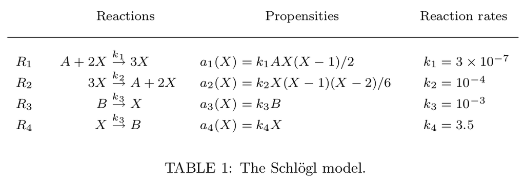

The Schlogl model definition in terms of reactions, propensities and reaction rates (adapted from: (S. Ilie and Jackson 2009)).

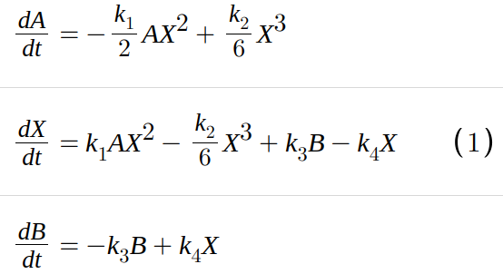

The concentrations of A and B are fixed, and the system is open with the exchange of chemical materials (Cao 2006) If the concentrations of A and B are equal, the system becomes to equilibrium. When the concentration of A and B are fixed, but different, the system shows two stable steady states as solutions for X1. We focus on the single state variable, one-dimensional deterministic bistable Schlogl model, and then to stochastic bistable system.

Since the molecular numbers for the species A and B are kept at constant values, A = 10^5 and B = 2 × 10^5 , then we can reduce the system of ODEs (1) in just one equation with the following Petri Net (PN) graph:

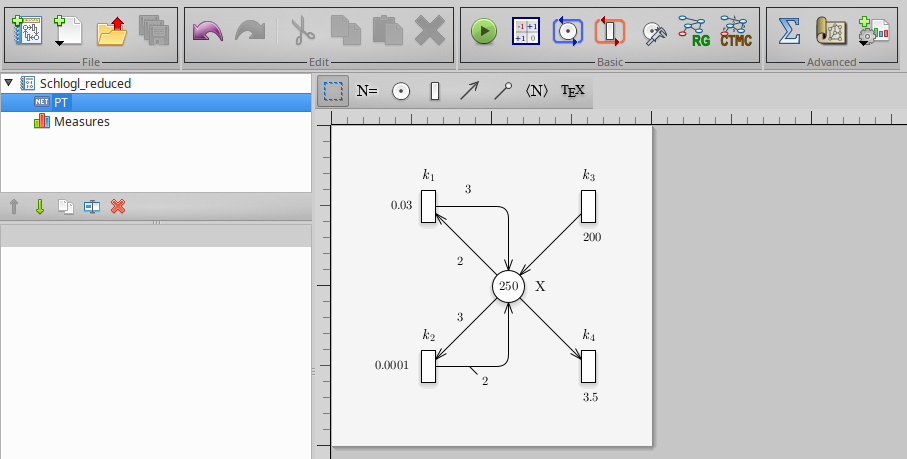

Petri Net representation of the reduced Schlogl model.

where:

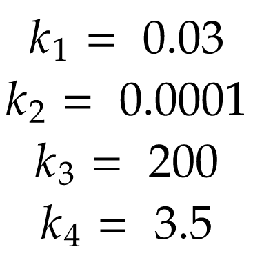

In the stochastic models, the initial condition for the number of molecules of species X is X(0) = 250. To obtain the two stable states in the deterministic state, we took the initial condition X(0) = 248 for the lower stable state and X(0) = 249 for the upper stable state. This exemplifies a bistable system which has two solutions under similar conditions.

### Model generation

The first step is the model construction. Starting with the GreatSPN editor tool it is possible to draw the model using the PN formalism and its generalizations. We recall that the Petri Nets are bipartite graphs in which we have two type of nodes, places and transitions. Graphically, places are represented as circles and those are the variables of our systems. On the other hand, transitions are depicted as rectangles and are the possible events happening in the system. Variables and events (i.e., places and transitions) are connected through arcs, showing what variable(s) is (are) affected by a specific event. For more details we refer to (Marsan et al. 1995)

Therefore, as represented in figure , we add one place and four transition. Finally, we save the PN model as a file with extension *.PNPRO* . Having constructed the model, the generation of both the stochastic (the Continuous Time Markov Chain) and deterministic (ODEs) processes underlying the model is implemented by the *model_generation()* function. This function takes as input the file generated by the graphical editor, in this case called *Schlogl_reduced.PNPRO*, and automatically derives the processes.

```
model_generation(net_fname = "./Net/Schlogl_reduced.PNPRO")
```

The binary file *Schlogl_reduced.solver* is generated in which the derived processes and the library used for their simulation are packaged.

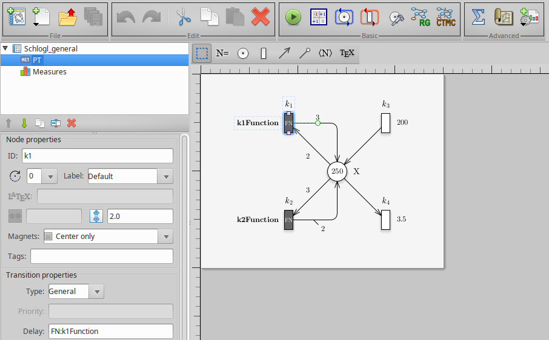

Petri Net representation of the reduced Schlogl model, modelling the k1 and k2 transition as general transitions

Then, we have to properly define a C++ function implementing the specific behavior of the transition and save it, for instance in a file named *transition.cpp*, which has to be structured as follow:

```
static double Flag = -1;
static double k1_rate;
static double k2_rate;

void read_constant(string fname, double& k1)
{
  ifstream f (fname);
  string line;
  if(f.is_open())
  {
    int i = 1;
    while (getline(f,line))
    {
      switch(i)
      {
      case 1:
        k1 = stod(line);
        // cout << "c" << i << ": " << line << "\t" << k1 << endl;
        break;
      }
      ++i;
    }
    f.close();
  }
  else
  {
    std::cerr<<"\nUnable to open " << fname << ": file do not exists\": file do not exists\n";
    exit(EXIT_FAILURE);
  }
}

void init_data_structures()
{
    read_constant("./k1", k1_rate);
  read_constant("./k2", k2_rate);
  Flag = 1;

}

double k1Function(double *Value,
                         map <string,int>& NumTrans,
                         map <string,int>& NumPlaces,
                         const vector<string> & NameTrans,
                         const struct InfTr* Trans,
                         const int T,
                         const double& time)
{

    // Definition of the function exploited to calculate the rate,
    // in this case for semplicity we define it throught the Mass Action law

    if( Flag == -1)   init_data_structures();

    double intensity = 1.0;

      double X = Value[Trans[T].InPlaces[0].Id];
      intensity = X * (X - 1);

    double rate = (k1_rate/2) * intensity;

    return(rate);
}

double k2Function(double *Value,
                  map <string,int>& NumTrans,
                  map <string,int>& NumPlaces,
                  const vector<string> & NameTrans,
                  const struct InfTr* Trans,
                  const int T,
                  const double& time)

{

  // Definition of the function exploited to calculate the rate,
  // in this case for simplicity we define it through the Mass Action law

  if( Flag == -1)   init_data_structures();

  double intensity = 1.0;

  double X = Value[Trans[T].InPlaces[0].Id];
  intensity = X * (X - 1) * (X - 2);

  double rate = (k2_rate/6) * intensity;

  return(rate);
}
```

Notice that the function name has to correspond to the rate name associated with the general transition, in this case there are two: *k1Function* and *k2function*.

Finally, the process can be derived by the *model_generation()* function as follow.

```
model_generation(net_fname = "./Net/Schlogl_general.PNPRO",
                 functions_fname = "./Cpp/transition.cpp")
```

### Model Analysis

After that the binary file is generated a following step could be the model analysis, where the corresponding function *model_analysis()* executes and tests the behavior of the developed model. Furthermore, by changing the input parameters, it is possible to perform a *what-if* analysis or forecasting the evolution of the diffusion process. This function solves the system given a specific parameters configuration which is passed through the function parameter, *parameters_fname*.

### Deterministic model

For the deterministic model considering the reaction rate equations (1), a solution converges to one of the two stable states as represented by figure , and stays in the neighborhood of that solution after a finite time.

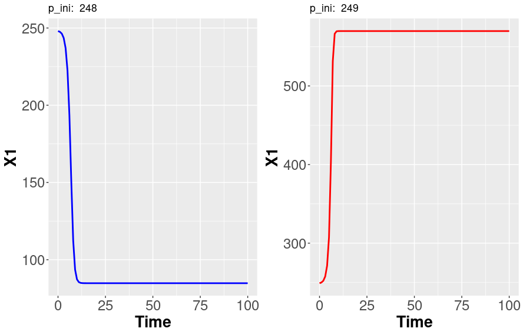

The Schlogl model: deterministic case

To produce the trajectory of figure the function *model_analysis()* is called. This function solves the system given a specific parameters configuration simulating the behaviour of the developed model. Furthermore, by changing the input parameters, it is possible to perform two analyses (X1(0) = 248 for the lower stable state and X1(0) = 249 for the upper stable state) and to forecast the bistability of the system.

```
model_analysis(solver_fname = "./Schlogl_general.solver",
               parameters_fname = "./Input/Functions_list_ModelAnalysis.csv",
               f_time = 100, # days
               s_time = 1
)
```

### Mass-action law considerations

The mass-action law, which predicts the rates of chemical reactions, is widely used for modelling the kinetics of the chemical reactions network and their stationary states. One of the hypotheses under which the mass-action law holds, and the mass-action equations are valid, is that the volume in which the reactions take place is ideally stirred. Assuming that, the system can be fully described in terms of the macroscopic concentrations (Brogioli 2013).

However, the mean-field approach, on which the mass-action law is based, neglects the effects of the small number of particles in the system (e. g. when a small number of molecules in a confined volume is considered). Indeed, possible configurational correlations might introduce a dependence on the volume. The approximation consists in neglecting deviations from mean values, i.e. the fluctuations. For independent statistical variables the approximation is valid in the limit of large particles (N ≫1). Taking into consideration the statistical description, the next simulation will show that how this description can be applied to several ensembles (among which reaction networks) of a reasonable generality.

```
double k1Function(double *Value,
                         map <string,int>& NumTrans,
                         map <string,int>& NumPlaces,
                         const vector<string> & NameTrans,
                         const struct InfTr* Trans,
                         const int T,
                         const double& time)
{

    // Definition of the function exploited to calculate the rate,
    // in this case for semplicity we define it throught the Mass Action law

    if( Flag == -1)   init_data_structures();

    double intensity = 1.0;

    for (unsigned int k=0; k<Trans[T].InPlaces.size(); k++)
    {
      intensity *= pow(Value[Trans[T].InPlaces[k].Id],Trans[T].InPlaces[k].Card);
    }

    double rate = (k1_rate/2) * intensity;

    return(rate);
}

double k2Function(double *Value,
                  map <string,int>& NumTrans,
                  map <string,int>& NumPlaces,
                  const vector<string> & NameTrans,
                  const struct InfTr* Trans,
                  const int T,
                  const double& time)

{

  // Definition of the function exploited to calculate the rate,
  // in this case for simplicity we define it through the Mass Action law

  if( Flag == -1)   init_data_structures();

  double intensity = 1.0;

  for (unsigned int k=0; k<Trans[T].InPlaces.size(); k++)
  {
    intensity *= pow(Value[Trans[T].InPlaces[k].Id],Trans[T].InPlaces[k].Card);
  }

  double rate = (k2_rate/6) * intensity;

  return(rate);
}
```

In the mean field approximation one replaces the interaction of a particle with its neighboring by an approximate interaction with an averaged number of particles. The so redid *k2Function* and *k2Function* functions solve the system given the mass action law approximation valid in the limit of large X1 >> 1. Now, it is possible to perform two analyses and to forecast the bistability of the system.

```
model_generation(net_fname = "./Net/Schlogl_general.PNPRO",
                 functions_fname = "./Cpp/transitions_apprx.cpp")
```

Considering the mean-field approximation we observed different stable states than without neglecting the effects of the small number of particles give the initial condition of chemical species X1: X1(0) = 247 for the lower stable state and X1(0) = 248 for the upper stable state as represented by figure .

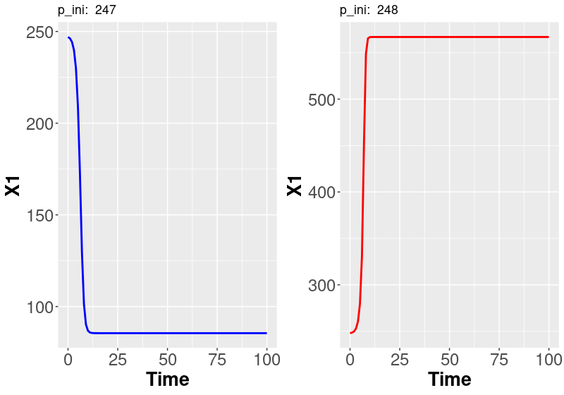

The Schlogl model: deterministic case and mass action law in chemical equilibrium considering the mean-field approximation

### Stochastic model

For the stochastic models, a trajectory may spontaneously switch between the two stable states due to the intrinsic noise of the system. Such qualitative behavior include noise-induced bi-stable systems, which are mono-stable in the deterministic setting.

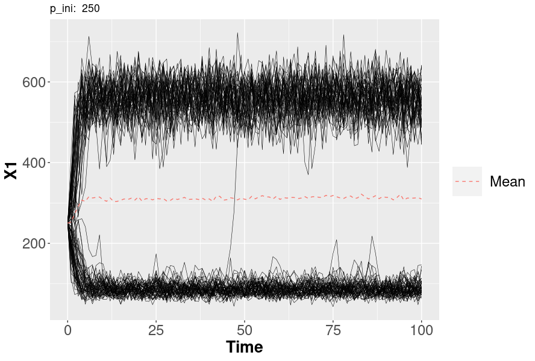

The Schlogl model: Chemical Master Equation model, 100 trajectories are shown. Stochastic simulations reveal that intrinsic noise in the network can induce one trajectory to spontaneously switch between stable states

Note that the reaction rates in the reaction rate equation correspond to the propensity functions in the Chemical Master Equation (Table 1).

Having constructed the model, the generation of both the stochastic and deterministic processes underlying the model is implemented by the *model_generation()* function. We use the Gillespie SSA, which is an exact stochastic method widely used to simulate chemical systems whose behaviour can be described by the Master equations.

```
model_analysis(solver_fname = "./Schlogl_general.solver",
               parameters_fname = "./Input/Functions_list_ModelAnalysis.csv",
               functions_fname = "./Rfunction/Functions.R",
               solver_type = "SSA",
               n_run = 100,
               parallel_processors = 2,
               f_time = 100, # days
               s_time = 1
)
```

### Sensitivity analysis

The second step is represented by the sensitivity analysis, in which the deterministic process is solved several times varying the values of the unknown parameters to identify which are the sensitive ones (i.e., those that have a greater effect on the model behavior), by exploiting the Pearson Ranking Correlation Coefficients (PRCCs). This may simplify the calibration step reducing (1) the number of variables to be estimated and (2) the search space associated with each estimated parameter. With this purpose, the function *sensitivity_analysis()* calculates the PRCCs, and, given a reference dataset and a distance measure, it ranks the simulations according to the distance of each solution with respect to the reference one.

Another example might be *Functions_list2.csv*, where we decide to vary the initial marking using the following function *init_generation* defined in the R script *Functions.R* (see *functions_fname* parameter).

```
init_generation<-function(min_init , max_init)
{
# min/max are vectors = first position interval values
# for the first place and second position for the second place
# It returns a vector of lenght equal to 1 since the marking is
# defined by the one places: X1
    p_1=runif(n=1,min=min_init[1],max=max_init[1])
    return(p_1)
}
```

```
Target<-function(output)
{
    ret <- output[,"X1"]
    return(as.data.frame(ret))
}
```

1. **reference_data**: a csv file storing the data to be compared with the simulations’ result. In *reference_data.csv* we proposed the Schlogl model evolution starting with 249 as X1’s initial marking which result in the upper steady-state, with equation rates given by Table 1. Notice that the **reference_data**’s rows must be the variable time series, and so the columns the corresponding values at a specific time.
2. **distance_measure_fname**: the R file storing the function to compute the distance (or error) between the model output and the reference dataset itself. The function defining the distance takes in input only the reference data and the simulation’s output (i.e. a trajectory); an example is given by *msqd.R* where a distance measure (based on the squared error distance) as function of the chemical species X1 is defined:

```
msqd<-function(reference, output)
{
  reference[1,] -> times_ref
  reference[2,] -> X1_ref

  # We will consider the same time points
  X1 <- output[which(output$Time %in% times_ref),"X1"]
  X1_ref <- X1_ref[which( times_ref %in% output$Time)]

  diff.X1 <- 1/length(times_ref)*sum(( X1 - X1_ref )^2 )

  return(diff.X1)
}
```

Let us observe that: (i) the distance and target functions must have the same name of the corresponding R file,(ii) *sensitivity_analysis* exploits also the parallel processing capabilities, and (iii) if the user is not interested on the ranking calculation then the **distance_measure_fname** and **reference_data** are not necessary and can be omitted.

1. **Sensitivity analysis with general transitions**: Let us consider the example of the Schlogl model where the *k1* and *k2* transitions is defined as general transition, with the purpose to varying the *k1_rate* and *k2_rate* constants of the corresponding Mass Action law. Generally, in order to define the rate of a transition it is required to provide some inputs and, hence, we need to define an R function (in the **functions_fname** file) which provides all the input parameters necessary to the C++ function.

Therefore, we have to modify the *Functions_list* csv as follow in order to associate with the general transitions *k1* and *k2* the R function, *k1ValuesGeneration* and *k2ValuesGeneration*, which generates the values exploited by the respective function defined in the C++ file, called *trasition.cpp*.

```
#>   Tag Name            Function Parameter1 Parameter2 Parameter3
#> 1   g   k1  k1ValuesGeneration        n=1      min=0      max=1
#> 2   g   k2  k2ValuesGeneration        n=1  min = 0.1      max=1
#> 3   p   k3               runif        n=1  min = 0.1      max=1
#> 4   p   k4               runif        n=1  min = 0.1      max=1
```

Successively, we have to define the *k1ValuesGeneration* and *k2ValuesGeneration* in *Functions.R*.

Notice that the value (or values) generated are temporarily saved in a file named as the corresponding name in the *Functions_list*. Hence, the file *transition.cpp* has to be modified in order to read and use the value generated from the R function *k1ValuesGeneration* and *k2ValuesGeneration*.

```
## Simple version where only the transition rates vary.
sensitivity<-sensitivity_analysis(n_config = 100,
                                  parameters_fname = "Input/Functions_list2.csv",
                                  solver_fname = "Schlogl_general.solver",
                                  reference_data = "Input/reference_data.csv",
                                  distance_measure_fname = "Rfunction/msqd.R" ,
                                  target_value_fname = "Rfunction/Target.R" ,
                                  f_time = 30, # days
                                  s_time = 1, # days
                                  parallel_processors = 2
)
```

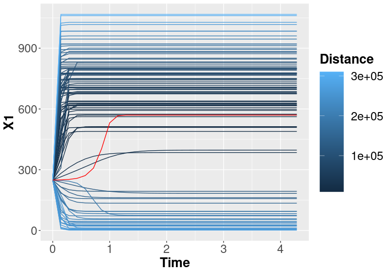

The 100 trajectories considering the X1 place obtained from different parameters configurations.

From the figure it is possible to observe the different trajectories obtained by solving the system of ODEs, represented by eq. 1, with different parameters configurations, sampled by exploiting the function passed through **parameters_fname**. In figure the distance values, obtained using the measure definition described before, are plotted varying the *k1* parameter (on the x-axis) and *k2* parameter (on the y-axis).

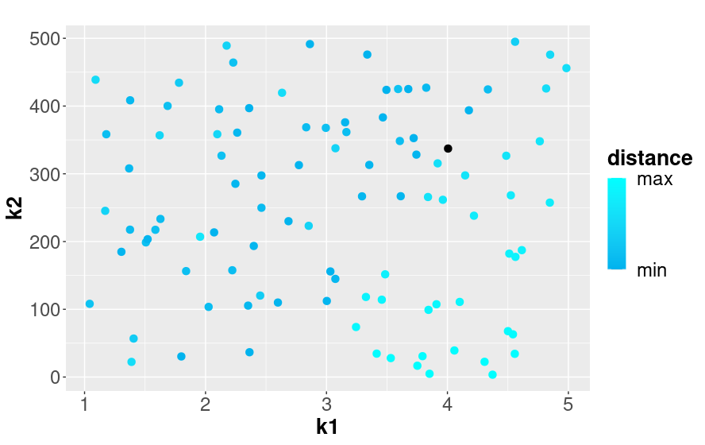

Each point is colored according to a nonlinear gradient function starting from color dark blue (i.e., lower value) and moving to color light blue (i.e., higher values).

### Calibration analysis

The aim of this phase is to optimize the fit of the simulated behavior to the reference data by adjusting the parameters associated with both *k1* and *k2* transitions. This step is performed by the function *model_calibration()*, characterized by the solution of an optimization problem in which the distance between the simulated data and the reference data is minimized, according to the definition of distance provided by the user (**distance_fname**)

The function input parameters are very similar to those introduced for the *sensitivity_analysis()*, we have just to modify the **parameters_fname** since we do not need to sample the parameter values. An example is given in *Functions_list_Calibration.csv*, where the first two columns (i.e., type and name) remain unchanged, differently the functions associated with each rate (defined *FunctionCalibration.R*) have to return the value (or a linear transformation) of the vector of the unknown parameters generated from the optimization algorithm, namely *x*, whose size is equal to number of parameters in **parameters_fname**. Let us note that the output of these functions must return a value for each input parameter.

```
#>   Tag Name       Function Parameter NA
#> 1   p   X1  X1Calibration       n=1 NA
#> 2   g   k1  k1Calibration       n=1 NA
#> 3   g   k2  k2Calibration       n=1 NA
```

```
X1Calibration<-function(x,n)
{
  return(x[1]*n)
}

k1Calibration<-function(x,n)
{
  return(x[2]*n)
}

k2Calibration<-function(x,n)
{
  return(x[3]*n)
}
```

```
model_calibration(parameters_fname = "Input/Functions_list_Calibration.csv",
                  functions_fname = "Rfunction/FunctionCalibration.R",
                  solver_fname = "Schlogl_general.solver",
                  reference_data = "Input/reference_data.csv",
                  distance_measure_fname = "Rfunction/msqd.R" ,
                  f_time = 30, # days
                  s_time = 1, # days
                  # Vectors to control the optimization
                  ini_v = c(247, 0.06, 0.0005),
                  ub_v = c(249, 0.08, 0.0002),
                  lb_v = c(248, 0.028, 0.00009),
                  max.time = 1
)
```

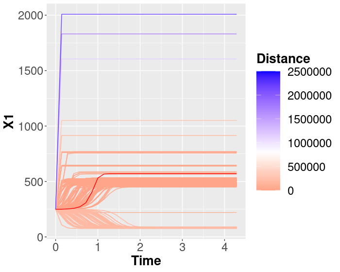

Trajectories considering the X1 place.

In figure , the trajectories with color depending on the squared error w.r.t. reference trend are plotted.

# References

Brogioli, D. 2013. “Violation of the Mass-Action Law in Dilute Chemical Systems.” *The Journal of Chemical Physics* 139.

Cao, Gillespie, Y. 2006. “Efficient Step Size Selection for the Tau-Leaping Simulation Method.” *The Journal of Chemical Physics*, no. 124.

E. M. Ozbudak, H. N. Lim, M. Thattai, and A. van Oudenaarden. 2004. “Multistability in the Lactose Utilization Network of Escherichia Coli.” *Nature*, no. 427: 737–40.

Marsan, M. Ajmone, G. Balbo, G. Conte, S. Donatelli, and G. Franceschinis. 1995. *Modelling with Generalized Stochastic Petri Nets*. New York, NY, USA: J. Wiley.

Pernice, S., M. Pennisi, G. Romano, A. Maglione, S. Cutrupi, F. Pappalardo, G. Balbo, M. Beccuti, F. Cordero, and R. A. Calogero. 2019. “A Computational Approach Based on the Colored Petri Net Formalism for Studying Multiple Sclerosis.” *BMC Bioinformatics*.

S. Ilie, W. H. Enright, and K. R. Jackson. 2009. “Numerical Solution of Stochastic Models of Biochemical Kinetics.” *Can. Appl. Math. Quart.* 17: 523–54.

Schlögl, F. 1972. “Chemical Reaction Models for Non-Equilibrium Phase Transitions.” *Zeitschrift Für Physik A Hadrons and Nuclei*, no. 253: 147–61.

Vellela, M., and H. Qian. 2009. “Stochastic Dynamics and Non-Equilibrium Thermodynamics of a Bistable Chemical System: The Schlögl Model Revisited.” *J. Roy. Soc.*